# Coursera Machine Learning Course Project

Joel Modisette

8/24/2021

## Background

Using devices such as Jawbone Up, Nike FuelBand, and Fitbit it is now possible to collect a large amount of data about personal activity relatively inexpensively. These type of devices are part of the quantified self movement – a group of enthusiasts who take measurements about themselves regularly to improve their health, to find patterns in their behavior, or because they are tech geeks. One thing that people regularly do is quantify how much of a particular activity they do, but they rarely quantify how well they do it.

In this project, we will use data from accelerometers on the belt, forearm, arm, and dumbell of 6 participants. They were asked to perform barbell lifts correctly and incorrectly in 5 different ways.

### Data Sources

The data consists of a Training data and a Test data (to be used to validate the selected model). This data sets may be found here:

https://d396qusza40orc.cloudfront.net/predmachlearn/pml-training.csv

https://d396qusza40orc.cloudfront.net/predmachlearn/pml-testing.csv

The source for this data project is:

http://web.archive.org/web/20161224072740/http:/groupware.les.inf.puc-rio.br/har

### Goal

The goal of this project is to predict the manner in which they did the exercise. This is the “classe” variable in the training set.

## Libraries and Data Loading

```r
library(caret); library(corrplot); library(dplyr); library(randomForest); library(rpart); library(rattle)

train_url <- "https://d396qusza40orc.cloudfront.net/predmachlearn/pml-training.csv"
test_url <- "https://d396qusza40orc.cloudfront.net/predmachlearn/pml-testing.csv"
train_file <- "pml-training.csv"
test_file <- "pml-testing.csv"

if(!file.exists(train_file)){
  download.file(train_url, train_file)
}
if(!file.exists(test_file)){
  download.file(test_url, test_file)
}
train <- read.csv(train_file, na.strings = c("NA", ""), stringsAsFactors = FALSE)
test <- read.csv(test_file, na.strings = c("NA", ""), stringsAsFactors = FALSE)
```

## Data Pre-processing

Remove columns with missing data or data unrelated to the objective “classe” variable in the training set. Make the “classe” variable a factor variable.

```r
#remove cols with all NA, timestamp, window, user, or X
train <- train[colSums(is.na(train)) == 0]
test <- test[colSums(is.na(test)) == 0]

train <- select(train,
                -contains("timestamp"), -contains("window"), -contains("user"), -X)
test <- select(test,
               -contains("timestamp"), -contains("window"), -contains("user"), -X)
```

Determine the values for “classe”

```r
table(train$classe)
```

```
##
##    A    B    C    D    E
## 5580 3797 3422 3216 3607
```

Convert the objective variable into a factor variable.

```r
train$classe <- as.factor(train$classe)
```

## Split Training Data

Creating training and test partitions within the training data give me the flexibility to build and compare. Use a 70-30 percent split.

```
## [1] "Training Data Dimension"
```

```
## [1] 13737    53
```

```
## [1] "Validation(pre-Test) Data Dimension"
```

```
## [1] 5885   53
```

### Determine the highest correlated variables with a threshold of r = 0.8

Currently have 52 predictor variables and one outcome “classe” factor variable.

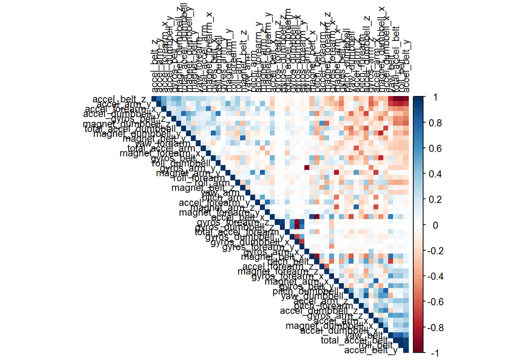

### Candidates for future study for data compression

No data compression was performed. The following variables would likely expected to contain most of the variability.

```r
highcorr = findCorrelation(cor_mat, cutoff=0.8)
print(names(train)[highcorr])
```

```
##  [1] "accel_belt_z"     "roll_belt"        "accel_belt_y"     "accel_dumbbell_z"
##  [5] "accel_belt_x"     "pitch_belt"       "accel_arm_x"      "accel_dumbbell_x"
##  [9] "magnet_arm_y"     "gyros_forearm_y"  "gyros_dumbbell_x" "gyros_dumbbell_z"
## [13] "gyros_arm_x"
```

## Build and Test Models

Use Classification Tree, Random Forests and Generalized Boosted Model.

### Classification Tree

Create the model using the training data, then plot the classification tree.

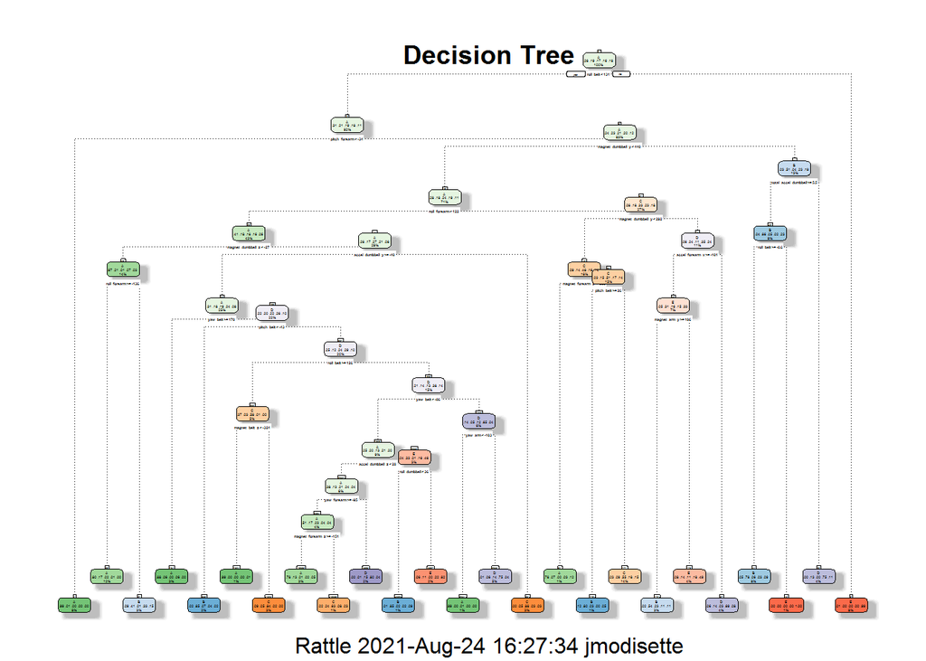

```r
set.seed(11111)
DT_Model <- rpart(classe ~ ., data=trainData, method="class")
rattle::fancyRpartPlot(DT_Model, main = "Decision Tree")
```

Validate the Decision Tree Model on the newly created test data partition of our training data.

```r
predictDT_Model <- predict(DT_Model, testData, type = "class")
cmDT <- confusionMatrix(predictDT_Model, testData$classe)
cmDT
```

```
## Confusion Matrix and Statistics
##
##           Reference
## Prediction    A    B    C    D    E
##          A 1522  167   12   49   13
##          B   58  706  100   79   96
##          C   47  109  819  148  139
##          D   25   94   67  609   52
##          E   22   63   28   79  782
##
## Overall Statistics
##
##                Accuracy : 0.7541
##                  95% CI : (0.7429, 0.7651)
##     No Information Rate : 0.2845
##     P-Value [Acc > NIR] : < 2.2e-16
##
##                   Kappa : 0.6885
##
##  Mcnemar's Test P-Value : < 2.2e-16
##
## Statistics by Class:
##
##                      Class: A Class: B Class: C Class: D Class: E
## Sensitivity            0.9092   0.6198   0.7982   0.6317   0.7227
## Specificity            0.9428   0.9298   0.9088   0.9516   0.9600
## Pos Pred Value         0.8633   0.6795   0.6490   0.7190   0.8029
## Neg Pred Value         0.9631   0.9106   0.9552   0.9295   0.9389
## Prevalence             0.2845   0.1935   0.1743   0.1638   0.1839
## Detection Rate         0.2586   0.1200   0.1392   0.1035   0.1329
## Detection Prevalence   0.2996   0.1766   0.2144   0.1439   0.1655
## Balanced Accuracy      0.9260   0.7748   0.8535   0.7917   0.8414
```

Plot the matrix of the results of the Decision Tree.

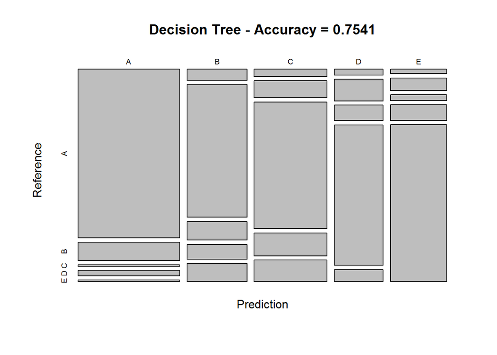

```r
plot(cmDT$table, col - cmDT$byClass,
     main = paste("Decision Tree - Accuracy =", round(cmDT$overall['Accuracy'],4)))
```

The accuracy rate of the Decision Tree is 0.7541.

## Random Forest

Create the Random Forest model using the training data.

```r
controlRF <- trainControl(method="cv", number=3, verboseIter=FALSE)
RF_model <- train(classe ~ ., data=trainData, method="rf", trControl=controlRF)
RF_model$finalModel
```

```
##
## Call:
##  randomForest(x = x, y = y, mtry = min(param$mtry, ncol(x)))
##                Type of random forest: classification
##                      Number of trees: 500
## No. of variables tried at each split: 27
##
##         OOB estimate of  error rate: 0.72%
## Confusion matrix:
##      A    B    C    D    E class.error
## A 3902    3    0    0    1 0.001024066
## B   16 2635    6    1    0 0.008653123
## C    0   17 2369   10    0 0.011268781
## D    0    1   29 2220    2 0.014209591
## E    0    1    5    7 2512 0.005148515
```

Validate the Random Forest model on our validation (test) data.

```r
predictRF1 <- predict(RF_model, newdata=testData)
cmrf <- confusionMatrix(predictRF1, testData$classe)
cmrf
```

```
## Confusion Matrix and Statistics
##
##           Reference
## Prediction    A    B    C    D    E
##          A 1673    5    0    0    0
##          B    0 1131   13    0    0
##          C    1    3 1011    8    0
##          D    0    0    2  955    0
##          E    0    0    0    1 1082
##
## Overall Statistics
##
##                Accuracy : 0.9944
##                  95% CI : (0.9921, 0.9961)
##     No Information Rate : 0.2845
##     P-Value [Acc > NIR] : < 2.2e-16
##
##                   Kappa : 0.9929
##
##  Mcnemar's Test P-Value : NA
##
## Statistics by Class:
##
##                      Class: A Class: B Class: C Class: D Class: E
## Sensitivity            0.9994   0.9930   0.9854   0.9907   1.0000
## Specificity            0.9988   0.9973   0.9975   0.9996   0.9998
## Pos Pred Value         0.9970   0.9886   0.9883   0.9979   0.9991
## Neg Pred Value         0.9998   0.9983   0.9969   0.9982   1.0000
## Prevalence             0.2845   0.1935   0.1743   0.1638   0.1839
## Detection Rate         0.2843   0.1922   0.1718   0.1623   0.1839
## Detection Prevalence   0.2851   0.1944   0.1738   0.1626   0.1840
## Balanced Accuracy      0.9991   0.9951   0.9915   0.9951   0.9999
```

The accuracy rate of the Random Forest is 0.9944. Explore the possibility of overfitting.

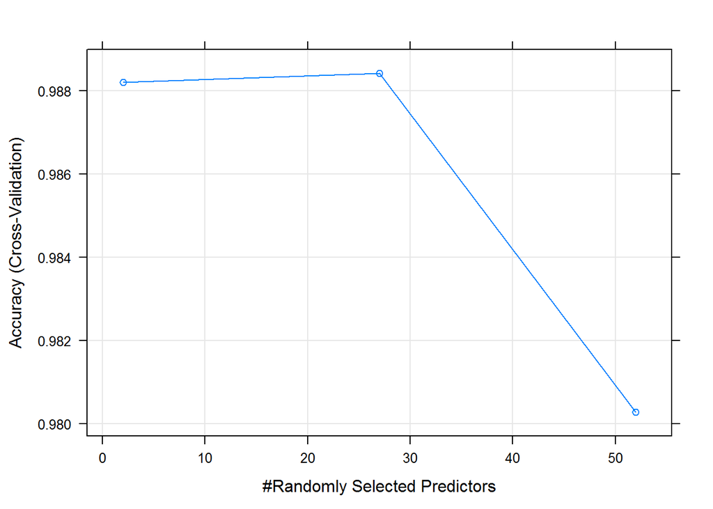

```r
plot(RF_model)
```

Plot the matrix of the results of the Random Forest.

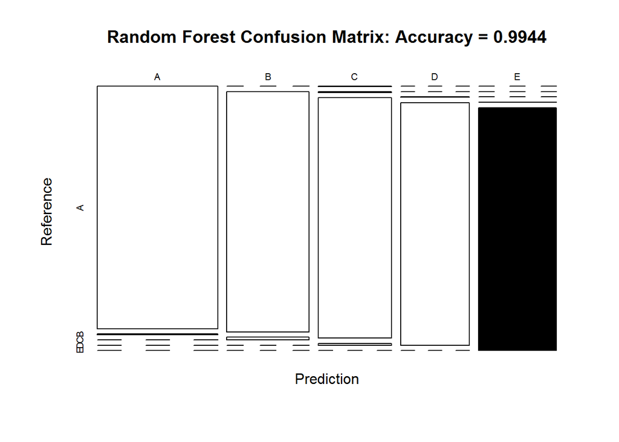

```r
plot(cmrf$table, col = cmrf$byClass, main = paste("Random Forest Confusion Matrix: Accuracy =", round(cmrf$overall['Accuracy'], 4)))
```

## Generalized Boosted Regression Model

Create the Generalized Boosted Regression model using the training data.

```r
set.seed(55555)
controlGBM <- trainControl(method = "repeatedcv", number = 5, repeats = 1)
GBM_model  <- train(classe ~ ., data=trainData, method = "gbm", trControl = controlGBM, verbose = FALSE)
GBM_model$finalModel
```

```
## A gradient boosted model with multinomial loss function.
## 150 iterations were performed.
## There were 52 predictors of which 52 had non-zero influence.
```

```r
print(GBM_model)
```

```
## Stochastic Gradient Boosting
##
## 13737 samples
##    52 predictor
##     5 classes: 'A', 'B', 'C', 'D', 'E'
##
## No pre-processing
## Resampling: Cross-Validated (5 fold, repeated 1 times)
## Summary of sample sizes: 10991, 10988, 10989, 10989, 10991
## Resampling results across tuning parameters:
##
##   interaction.depth  n.trees  Accuracy   Kappa
##   1                   50      0.7480530  0.6804629
##   1                  100      0.8204107  0.7727587
##   1                  150      0.8525857  0.8134463
##   2                   50      0.8557182  0.8172075
##   2                  100      0.9031079  0.8773809
##   2                  150      0.9295327  0.9108210
##   3                   50      0.8956820  0.8679398
##   3                  100      0.9393603  0.9232590
##   3                  150      0.9584341  0.9474013
##
## Tuning parameter 'shrinkage' was held constant at a value of 0.1
##
## Tuning parameter 'n.minobsinnode' was held constant at a value of 10
## Accuracy was used to select the optimal model using the largest value.
## The final values used for the model were n.trees = 150, interaction.depth =
##  3, shrinkage = 0.1 and n.minobsinnode = 10.
```

Validate the GBM on the test data.

```r
predictGBM <- predict(GBM_model, newdata=testData)
cmGBM <- confusionMatrix(predictGBM, testData$classe)
cmGBM
```

```
## Confusion Matrix and Statistics
##
##           Reference
## Prediction    A    B    C    D    E
##          A 1653   27    0    2    2
##          B   14 1081   34    4    8
##          C    5   31  977   22   11
##          D    2    0   14  930    7
##          E    0    0    1    6 1054
##
## Overall Statistics
##
##                Accuracy : 0.9677
##                  95% CI : (0.9629, 0.9721)
##     No Information Rate : 0.2845
##     P-Value [Acc > NIR] : < 2.2e-16
##
##                   Kappa : 0.9592
##
##  Mcnemar's Test P-Value : 0.0002289
##
## Statistics by Class:
##
##                      Class: A Class: B Class: C Class: D Class: E
## Sensitivity            0.9875   0.9491   0.9522   0.9647   0.9741
## Specificity            0.9926   0.9874   0.9858   0.9953   0.9985
## Pos Pred Value         0.9816   0.9474   0.9340   0.9759   0.9934
## Neg Pred Value         0.9950   0.9878   0.9899   0.9931   0.9942
## Prevalence             0.2845   0.1935   0.1743   0.1638   0.1839
## Detection Rate         0.2809   0.1837   0.1660   0.1580   0.1791
## Detection Prevalence   0.2862   0.1939   0.1777   0.1619   0.1803
## Balanced Accuracy      0.9900   0.9682   0.9690   0.9800   0.9863
```

## Selection of best model using validation data

Compare the three models:

[output not shown]

The Random Forest has the highest accuracy. Further study should involve parametric reduction and re-comparison of the methods. Choose the Random Forest to provide results for submission using the 20 row test data.

## Results using test data

```r
Results <- predict(RF_model, newdata=test)
Results
```

```
##  [1] B A B A A E D B A A B C B A E E A B B B
## Levels: A B C D E
```